# Virtual Lab Handout

JP

8/22/2021

Notes for Virtual Lab

# Steps to get on the Virtual Lab’s SPSS Account

1. Start with link to the lab https://www.cpp.edu/it/virtual-software-lab/index.shtml
2. Go with the General Lab and click on Enter General Lab.

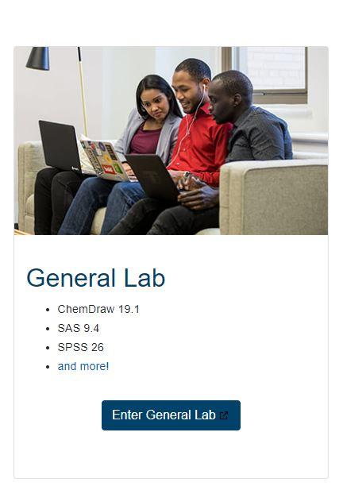

3. It will then take you to a different page where you will get a loading screen while your session is being prepared.

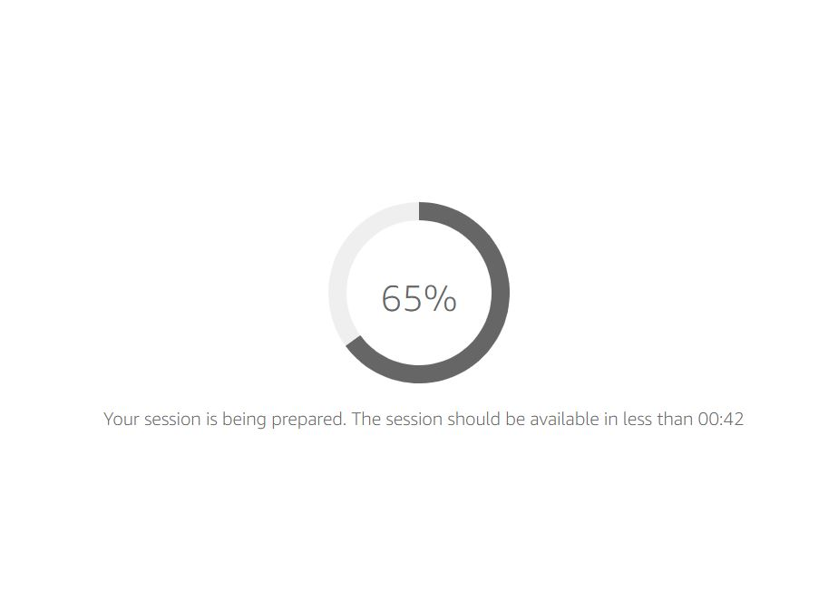

4. When loaded, you’ll be on the desktop screen.

[figure not shown]

5. Then click on **Installed Applications**

[figure not shown]

6. From the list, you’ll click on IBM SPSS Statistics 26. It will take a while to open up.
7. You’re now on SPSS and ready to work on some analyses.

# Extra Considerations When Working on The Virtual Lab.

**Important** Make sure you set up your OneDrive account with your @cpp.edu email address or you will not be able to save your work. You’ll also need your OneDrive to download the data and put it in your own account. You can delete it after the class.

To sign in to your OneDrive, you can google OneDrive and then when it asks you to sign in, you should use your @cpp.edu email address. Afterward, just bookmark the webpage so then you will always have it.

To double-check that you have the data in your OneDrive, you will click on the open folder on the top left on your virtual desktop.

[figure not shown]

**For those with chromebooks** There is not an easy way to download R without going through Linux, which is not worth the time and headache. Instead, you can use R through the virtual lab. You’ll see R x64 4.0.0 in the list of applications. When done with the problem set questions, you can then save the script in your OneDrive account.